# EA - Analisis OVNIs

# Intro

En este projecto usaremos el fichero de datos “scrubbed.csv” obtenido en https://www.kaggle.com/datasets/NUFORC/ufo-sightings. Elimininaremos datos de tipo NA y cambiaremos paises vacios (i.e. pais == ““) por”*Otros*”. Tambien arreglamos el formato de los datos con la libreria *lubridate*. Usamos la libreria *dplyr* para eliminar columnas no necesarias.

```r
# Leemos datos de CSV
datos <- read.csv("scrubbed.csv")

# Reemplacamos paises "" por "Otros"
datos$country <- ifelse(datos$country=="","otros",datos$country)

# Formateamos datos
datos$datetime <- as.POSIXct(datos$datetime, format =  "%m/%d/%Y %H:%M")
datos$'duration (seconds)' <- as.integer(datos$'duration..seconds.')
datos$latitude <- as.numeric(datos$latitude)

# Eliminamos datos NA
datos <- na.omit(datos)

library(dplyr)

datos <- datos %>% select(-one_of('duration..seconds.', 'duration..hours.min.', 'date.posted'))
```

Analisando los datos por pais, podemos ver que la mayoria de los OVNIs reportados son en EEUU. Usaremos la libreria *ggplot2* para generar diagrama, y representamos el diagrama de numero de OVNIs por pais

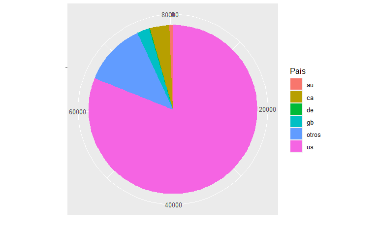

```r
by_country <- aggregate(datos$country, by=list(Country = datos$country), FUN=length)

library(ggplot2)

ggplot(by_country, aes(x="", y=by_country$x, fill=by_country$Country)) +
  geom_bar(stat="identity", width=1) +
  coord_polar("y", start=0) +
  xlab("") +
  ylab("") +
  guides(fill = guide_legend(title = "Pais"))
```

Por eso, hemos decidido hacer nuestros analisis sobre datos solamente de EEUU. Tomamos una prueba de tamaño 1000

```r
datos_us <- datos[which(datos$country == 'us'),]

datos_us <- datos_us %>% select(-country)

datos_us <- datos_us[sample(nrow(datos_us), 1000), ]
```

# Tema 3 - Estadística Descriptiva y Regresión (Axel)

De la prueba de 1000 datos, se ha hecho el análisis solamente de las variables cuantitativas, las cuales son: (“datetime, latitude, longitude, duration(seconds)”) Con el comando names(object…) se puede ver todas las columnas del fichero de datos y las referenciadas anteriormente

```r
names(datos_us)
```

```
[1] "datetime"           "city"               "state"              "shape"              "comments"           "latitude"
[7] "longitude"          "duration (seconds)"
```

## Medidas de Posición - Tendencia Central y No Central

Con `summary(object...)` podemos ver la media, mediana y percentiles de varios datos, para calcular la moda usamos la funcion *mode*

#datetime

```r
summary(datos_us$datetime)
```

```
                 Min.               1st Qu.                Median                  Mean               3rd Qu.                  Max.
"1920-06-11 21:00:00" "2001-10-15 16:01:30" "2007-09-24 08:27:30" "2004-07-19 11:57:36" "2012-01-06 11:56:15" "2014-05-08 00:00:00"
```

```r
mode <- function(x) {
  ux <- unique(x)
  ux[which.max(tabulate(match(x, ux)))]
}

print(paste("Moda: ", mode(datos_us$datetime)))
```

```
[1] "Moda:  2010-07-04 22:30:00"
```

#latitude

```r
summary(datos_us$latitude)
```

```
   Min. 1st Qu.  Median    Mean 3rd Qu.    Max.
  18.38   34.24   39.11   38.46   42.09   61.60
```

```r
mode <- function(x) {
  ux <- unique(x)
  ux[which.max(tabulate(match(x, ux)))]
}

print(paste("Moda: ", mode(datos_us$latitude)))
```

```
[1] "Moda:  47.6063889"
```

#longitude

```r
summary(datos_us$longitude)
```

```
   Min. 1st Qu.  Median    Mean 3rd Qu.    Max.
-157.86 -116.33  -90.05  -96.13  -80.78  -65.83
```

```r
mode <- function(x) {
  ux <- unique(x)
  ux[which.max(tabulate(match(x, ux)))]
}

print(paste("Moda: ", mode(datos_us$longitude)))
```

```
[1] "Moda:  -122.3308333"
```

#duration (seconds)

```r
summary(datos_us$'duration (seconds)')
```

```
   Min. 1st Qu.  Median    Mean 3rd Qu.    Max.
      0      30     180    4870     900 2631600
```

```r
mode <- function(x) {
  ux <- unique(x)
  ux[which.max(tabulate(match(x, ux)))]
}

print(paste("Moda: ", mode(datos_us$'duration (seconds)')))
```

```
[1] "Moda:  300"
```

## Medidas de Dispersión

No se ha considerado necesario calcular la varianza y desviación poblacional

| Medida | Formula |
| --- | --- |
| Cuasivarianza | var(x) |
| Cuasidesviación típica | sd(x) |
| Coeficiente de variación | coef_var(x) |

#duration (seconds)

```r
varianza <- var(datos_us$'duration (seconds)')
print(paste("Cuasivarianza: ", varianza))
```

```
[1] "Cuasivarianza:  7461474451.89896"
```

```r
sd <- sd(datos_us$'duration (seconds)')
print(paste("Cuasidesviación típica: ", sd))
```

```
[1] "Cuasidesviación típica:  86379.8266489286"
```

```r
coef_var <- function(x) {
  sd(x) / mean(x)
}
cv <- coef_var(datos_us$'duration (seconds)')
print(paste("Coeficiente de variación: ", cv))
```

```
[1] "Coeficiente de variación:  17.7360818598261"
```

#latitude

```r
varianza <- var(datos_us$latitude)
print(paste("Cuasivarianza: ", varianza))
```

```
[1] "Cuasivarianza:  30.4792348317191"
```

```r
sd <- sd(datos_us$latitude)
print(paste("Cuasidesviación típica: ", sd))
```

```
[1] "Cuasidesviación típica:  5.52080019849651"
```

```r
coef_var <- function(x) {
  sd(x) / mean(x)
}
cv <- coef_var(datos_us$latitude)
print(paste("Coeficiente de variación: ", cv))
```

```
[1] "Coeficiente de variación:  0.143561979912861"
```

#longitude

```r
varianza <- var(datos_us$longitude)
print(paste("Cuasivarianza: ", varianza))
```

```
[1] "Cuasivarianza:  337.666817315944"
```

```r
sd <- sd(datos_us$longitude)
print(paste("Cuasidesviación típica: ", sd))
```

```
[1] "Cuasidesviación típica:  18.3757127022585"
```

```r
coef_var <- function(x) {
  sd(x) / mean(x)
}
cv <- coef_var(datos_us$longitude)
print(paste("Coeficiente de variación: ", cv))
```

```
[1] "Coeficiente de variación:  -0.191145416104571"
```

#datetime

```r
varianza <- var(datos_us$datetime)
print(paste("Cuasivarianza: ", varianza))
```

```
[1] "Cuasivarianza:  121339714091724352"
```

```r
sd <- sd(datos_us$datetime)
print(paste("Cuasidesviación típica: ", sd))
```

```
[1] "Cuasidesviación típica:  348338505.037448"
```

## Medidas de Forma(Usar si no funciona: install.packages(“moments”))

#latitude Al calcular la asimetría y curtosis de la latitud determinamos que: *Obtenemos una asimetría negativa, por tanto la mayoría de datos se encuentran a la derecha de la media.* Obtenemos una curtosis mayor que cero, por tanto, hay una mayor concentración de datos alrededor de la media

```r
library(moments)
x <- (datos_us$latitude)
print(kurtosis(x))
```

```
[1] 3.516001
```

```r
print(skewness(x))
```

```
[1] -0.1583983
```

```r
print(mean(x))
```

```
[1] 38.45587
```

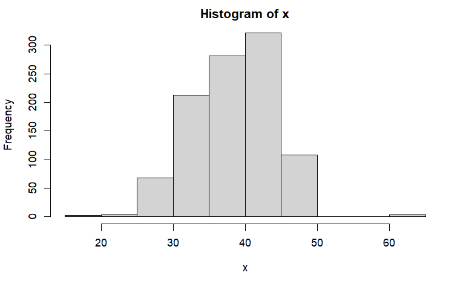

```r
hist(x)
```

```r
library(moments)
x <- (datos_us$longitude)
print(kurtosis(x))
```

```
[1] 2.046083
```

```r
print(skewness(x))
```

```
[1] -0.4237985
```

```r
print(mean(x))
```

```
[1] -96.13473
```

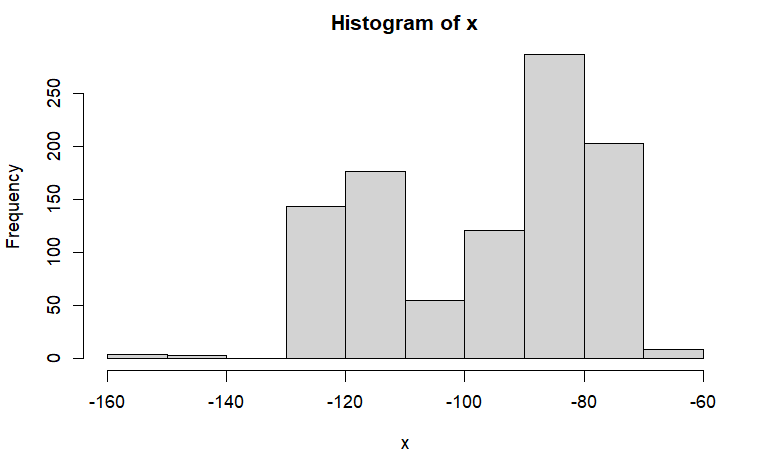

```r
hist(x)
```

#datetime Al calcular la asimetría y curtosis de la latitud determinamos que: *Obtenemos una asimetría negativa, por tanto la mayoría de datos se encuentran a la derecha de la media.* Obtenemos una curtosis mayor que cero, por tanto, hay una mayor concentración de datos alrededor de la media

```r
library(moments)
x <- (datos_us$datetime)
print(kurtosis(x))
```

```
[1] 10.78642
```

```r
print(skewness(x))
```

```
[1] -2.449666
```

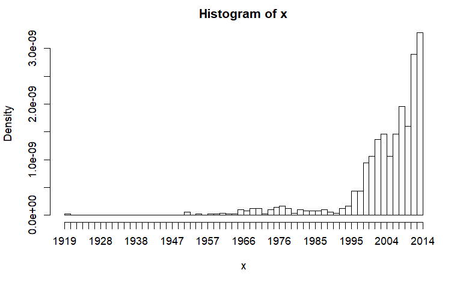

```r
hist(x, 50)
```

#duration (seconds) Al calcular la asimetría y curtosis de la latitud determinamos que: *Obtenemos una asimetría positiva, por tanto la mayoría de datos se encuentran a la izquierda de la media.* Obtenemos una curtosis mayor que cero, por tanto, hay una mayor concentración de datos alrededor de la media

```r
library(moments)
x <- (datos_us$'duration (seconds)')
print(kurtosis(x))
```

```
[1] 859.4062
```

```r
print(skewness(x))
```

```
[1] 28.57354
```

```r
print(mean(x))
```

```
[1] 4870.288
```

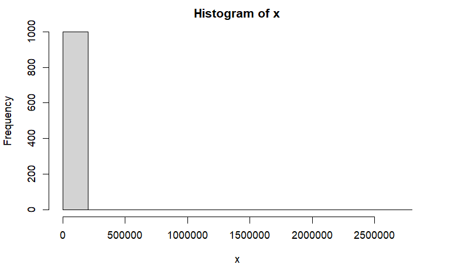

```r
hist(x)
```

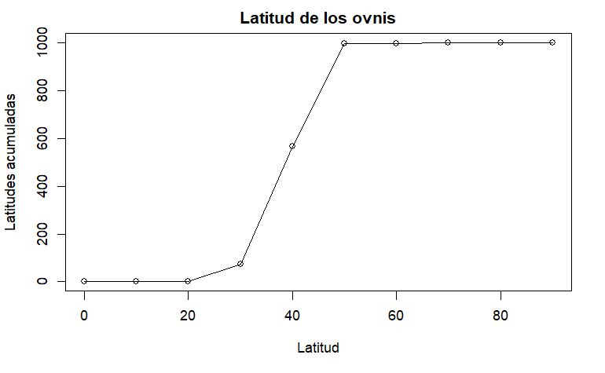

```r
lat <- datos_us$latitude
breaks <- seq(0, 90, by=10)
lat.cut <- cut(lat, breaks, right = FALSE)
lat.freq <- table(lat.cut)
lat.cumfreq <- c(0,cumsum(lat.freq))
plot(breaks, lat.cumfreq,
     main="Latitud de los ovnis",
     xlab = "Latitud",
     ylab = "Latitudes acumuladas")
lines(breaks, lat.cumfreq)
```

#longitude

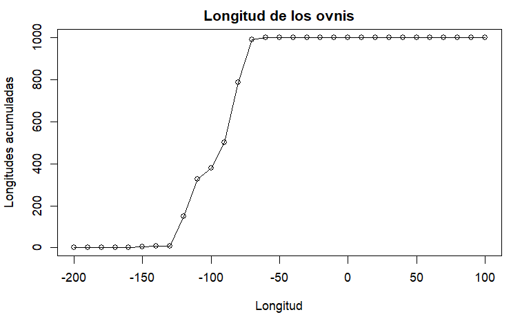

```r
longitude <- datos_us$longitude
breaks <- seq(-200, 100, by=10)
longitude.cut <- cut(longitude, breaks, right = FALSE)
longitude.freq <- table(longitude.cut)
longitude.cumfreq <- c(0,cumsum(longitude.freq))
plot(breaks, longitude.cumfreq,
     main="Longitud de los ovnis",
     xlab = "Longitud",
     ylab = "Longitudes acumuladas")
lines(breaks, longitude.cumfreq)
```

# Tema 4 - Probabilidad (Fonsi)

Probabilidad de ser de cada pais en caso de avistar un ovni

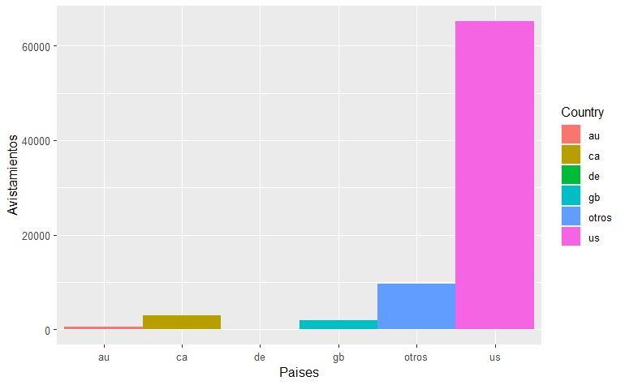

```r
dat <- read.csv("scrubbed.csv")
dat_country<-aggregate(dat$country, by=list(Country = dat$country), FUN=length)
dat$country <- ifelse(dat$country=="","otros",dat$country)
numAvistamientos<-sum(dat_country$x)
proobau1<-dat_country[which(dat_country$Country == 'au'),]
proobau2<-dat_country[which(dat_country$Country == 'ca'),]
proobau3<-dat_country[which(dat_country$Country == 'de'),]
proobau4<-dat_country[which(dat_country$Country == 'gb'),]
proobau5<-dat_country[which(dat_country$Country == 'us'),]
proobau6<-dat_country[which(dat_country$Country == ''),]
probbauval1<-(proobau1$x/numAvistamientos)*100
probbauval2<-(proobau2$x/numAvistamientos)*100
probbauval3<-(proobau3$x/numAvistamientos)*100
probbauval4<-(proobau4$x/numAvistamientos)*100
probbauval5<-(proobau5$x/numAvistamientos)*100
probbauval6<-(proobau6$x/numAvistamientos)*100




ggplot(by_country, aes(x=by_country$Country, y=by_country$x, fill=by_country$Country)) +
  geom_bar(stat="identity", width=1) +
  xlab('Paises') +
  ylab('Avistamientos') +
  guides(fill = guide_legend(title = "Country" ))
```

```r
print(paste("La probabilidad de avistar un ovni en Australia es del: ",probbauval1,"%"))
```

```
[1] "La probabilidad de avistar un ovni en Australia es del:  0.669720659264054 %"
```

```r
print(paste("La probabilidad de avistar un ovni en Canadá es del: ",probbauval2,"%"))
```

```
[1] "La probabilidad de avistar un ovni en Canadá es del:  3.73450181745755 %"
```

```r
print(paste("La probabilidad de avistar un ovni en Alemania es del: ",probbauval3,"%"))
```

```
[1] "La probabilidad de avistar un ovni en Alemania es del:  0.130707563611014 %"
```

```r
print(paste("La probabilidad de avistar un ovni en Gran Bretaña es del: ",probbauval4,"%"))
```

```
[1] "La probabilidad de avistar un ovni en Gran Bretaña es del:  2.37140865408555 %"
```

```r
print(paste("La probabilidad de avistar un ovni en Estados Unidos es del: ",probbauval5,"%"))
```

```
[1] "La probabilidad de avistar un ovni en Estados Unidos es del:  81.056117113977 %"
```

```r
print(paste("La probabilidad de avistar un ovni en otros países es del: ",probbauval6,"%"))
```

```
[1] "La probabilidad de avistar un ovni en otros países es del:  12.0375441916048 %"
```

Debido a que es en Estados Unidos donde hay mayor probabilidad de avistar un UFO vamos a calcular las ciudades donde es mas probable lograrlo

```r
by_city <- aggregate(datos_us$city, by=list(City = datos_us$city), FUN=length)

avistTot<-sum(by_city$x)
mostseek<-by_city[which(by_city$x>200),]

maxcity<-by_city[which(by_city$x == max(by_city$x)),]
print(paste("La ciudad con mayor probabilidad de avistar un ovni es",maxcity$City,"con una probabilidad de un ",(maxcity$x/avistTot)*100,"%"))
```

```
[1] "La ciudad con mayor probabilidad de avistar un ovni es seattle con una probabilidad de un  0.804767170414056 %"
```

```r
print(paste("A continuación se muestra una gráfica con las ciudades donde mayor probabilidad hay de avistar un ovni"))
```

```
[1] "A continuación se muestra una gráfica con las ciudades donde mayor probabilidad hay de avistar un ovni"
```

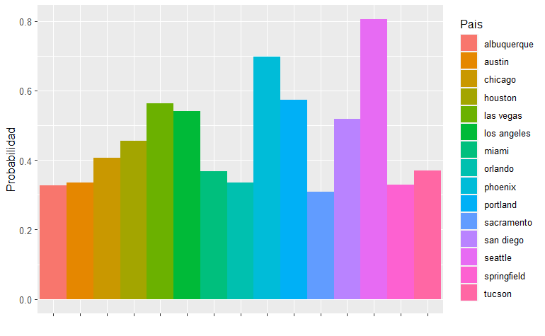

```r
ggplot(mostseek, aes(x=mostseek$City, y=(mostseek$x/avistTot)*100, fill=mostseek$City)) +
  geom_bar(stat="identity", width=1) +
  xlab('') +
  ylab('Probabilidad') +
  theme(axis.text.x=element_blank())+
  guides(fill = guide_legend(title = "Pais" ))
```

```r
anios<- aggregate(datos_us$city, by=list(Date = format(datos_us$datetime,"%Y")), FUN=length)
maxanio<-anios[which(anios$x == max(anios$x)),]

print(paste("El año con mayor probabilidad en caso de avistamiento fué",maxanio$Date,"con una probabilidad del",(maxanio$x/avistTot)*100,"%"))
```

[output not shown]

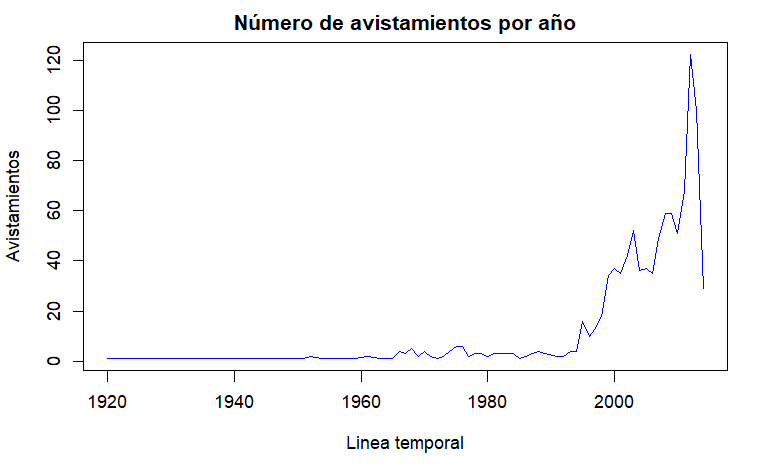

```r
plot(anios$Date,anios$x,type="l",col="blue", xlab = "Linea temporal", ylab = "Avistamientos", main = "Número de avistamientos por año")
```

```r
by_shape <- aggregate(datos_us$shape, by=list(shape = datos_us$shape), FUN=length)
max_shape<-sum(by_shape$x)
maxshape<-by_shape[which(by_shape$x == max(by_shape$x)),]
minshape<-by_shape[which(by_shape$x == min(by_shape$x)),]
print(paste("El ovni mas probabilidad de ser avistado son aquellos ovnis con forma",maxshape$shape,"con una probabilidad del",(maxshape$x/avistTot)*100,"%"))
```

```
[1] "El ovni mas probabilidad de ser avistado son aquellos ovnis con forma light con una probabilidad del 20.6920383339477 %"
```

```r
print(paste("Mientras que los más raros con mayor dificultad de avistamiento son aquellos con forma"))
```

```
[1] "Mientras que los más raros con mayor dificultad de avistamiento son aquellos con forma"
```

```r
print (paste(minshape$shape))
```

```
[1] "changed"  "crescent" "flare"    "hexagon"  "pyramid"
```

```r
print(paste("con una probabilidad del",(minshape$x[1]/avistTot)*100,"%"))
```

```
[1] "con una probabilidad del 0.00153581521071385 %"
```

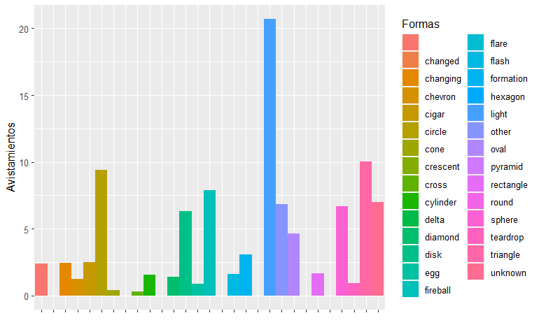

```r
ggplot(by_shape, aes(x=by_shape$shape,y=(by_shape$x/max_shape)*100,fill=by_shape$shape)) +
  geom_bar(stat="identity", width=1) +
  xlab('') +
  ylab('Avistamientos') +
theme(axis.text.x=element_blank())+
  guides(fill = guide_legend(title = "Formas" ))
```

```r
NA
NA
```

# Tema 5 - Variables Aleatorias y Modelos de Probabilidad (Sergio)

# Tema 6 - Muestreo, Estimación Puntual y por Intervalos de Confianza (Iñigo)

Vamos a construir un intervalo de confianza del 95% para la duracion media de los avistamientos en EEUU.

```r
datos <- read.csv("scrubbed.csv")#dataframe
datos_us <- datos[which(datos$country == "us"), ]#filtro por pais Estados Unidos
datos_us$"duration..seconds." <- as.integer(datos_us$"duration..seconds.")#convierto los valores a integer
datos_us <- datos_us[!is.na(datos_us$duration..seconds.), ]#eliminar NAs (en caso de que no se pudiera convertir a int algun valor)
retval <- subset(datos_us, duration..seconds. < 7201, select = c(state, duration..seconds.))#filtro por duracion menor o igual a 7200, para descartar valores muy altos que son inútiles nuestro análisis

intervalo <- t.test(retval$duration..seconds., conf.level = 0.95)#sacamos el intervalo de confianza
print(intervalo$conf.int)#intervalo de confianza
```

```
[1] 593.1504 611.1771
attr(,"conf.level")
[1] 0.95
```

```r
print(mean(retval$duration..seconds.))#media
```

```
[1] 602.1637
```

```r
print(paste("El resultado indica que la media de la variable duracion (seconds) es de ", mean(retval$duration..seconds.), " el cual se encuentra con una confianza del 95% en el intervalo ", intervalo$conf.int[1], " ", intervalo$conf.int[2]))
```

```
[1] "El resultado indica que la media de la variable duracion (seconds) es de  602.163722283944  el cual se encuentra con una confianza del 95% en el intervalo  593.150376554972   611.177068012916"
```

```
[1] 105 168
```

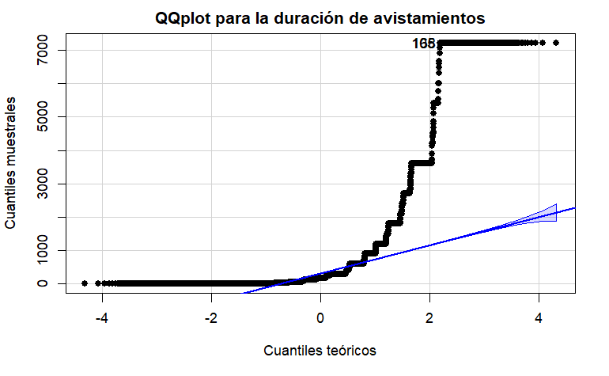

```r
car::qqPlot(retval$duration..seconds., pch=19,
       main='QQplot para la duración de avistamientos',
       xlab='Cuantiles teóricos',
       ylab='Cuantiles muestrales')
```

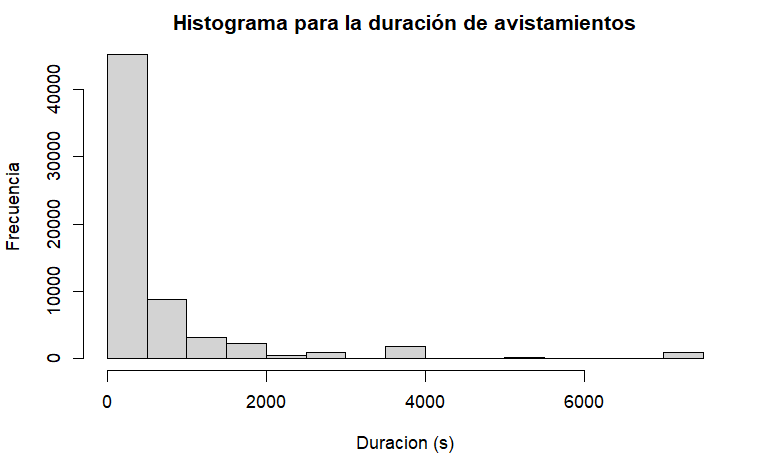

```r
hist(retval$duration..seconds., freq=TRUE,
     main='Histograma para la duración de avistamientos',
     xlab='Duracion (s)',
     ylab='Frecuencia')
```

```r
     #Podemos observar que la mayoría de avistamientos duran muy poco tiempo.
```

# Tema 7 - Contrastes de Hipótesis (Nico)